# Best Practices in R

Data analysis and visualization

Diego Angeles-Valdez

03 juni, 2025

## The Dataset

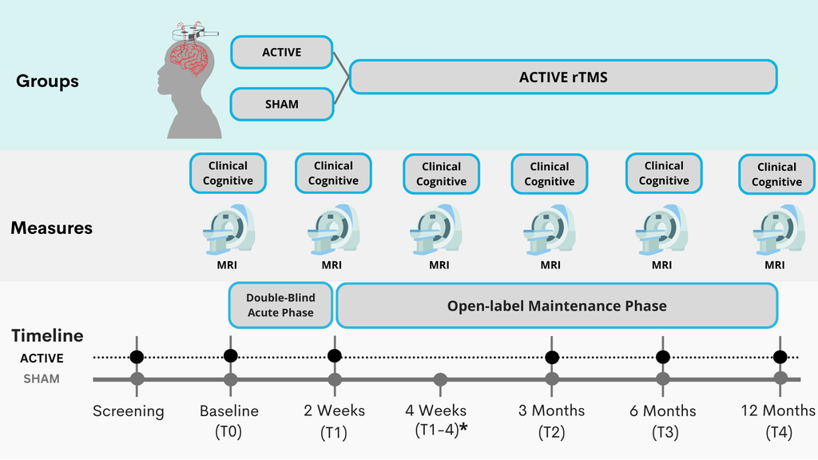

## Outline

- Tables & Figures
- t-test
- Correlation analysis
- Lineal regression
  - Linear regression with grouped

## Load R packages

```r
library(pacman)
pacman::p_load(tidyverse,table1)
```

## Load data

```r
data_demo <- read.csv("../data/Demographic_data.csv")
data_BIS <- read.csv("../data/SUDMEX_BIS.csv")
data_HDRS <- read.csv("../data/SUDMEX_HDRS.csv")
```

Tip: *Always keep in mind your research question.*

## Explore the dataset

```r
glimpse(data_BIS)
```

```
## Rows: 153
## Columns: 37
## $ rid       <int> 1, 1, 1, 2, 2, 2, 2, 2, 2, 3, 3, 3, 3, 4, 4, 4, 4, 4, 5, 5, …
## $ group     <int> 1, 1, 1, 1, 1, 1, 1, 1, 1, 2, 2, 2, 2, 2, 2, 2, 2, 2, 1, 1, …
## $ stage     <chr> "T0", "T1", "T4", "T0", "T1", "T1-4", "T2", "T3", "T4", "T0"…
## $ q1        <int> 0, 0, 4, 4, 4, 4, 4, 3, 1, 1, 3, 3, 1, 0, 3, 4, 3, 1, 0, 3, …
## $ q2        <int> 4, 1, 1, 1, 3, 0, 0, 3, 1, 3, 1, 1, 3, 3, 1, 1, 1, 3, 1, 1, …
## $ q3        <int> 0, 0, 0, 4, 4, 4, 3, 4, 4, 1, 3, 1, 1, 0, 1, 1, 1, 4, 3, 3, …
## $ q4        <int> 4, 4, 4, 4, 4, 4, 4, 4, 3, 3, 3, 3, 3, 4, 4, 1, 1, 4, 3, 3, …
## $ q5        <int> 4, 3, 0, 4, 4, 4, 4, 3, 3, 3, 3, 1, 1, 0, 3, 1, 0, 0, 3, 4, …
## $ q6        <int> 0, 1, 0, 4, 3, 4, 4, 1, 3, 0, 1, 1, 1, 0, 3, 3, 1, 0, 3, 3, …
## $ q7        <int> 0, 0, 0, 3, 1, 3, 3, 0, 3, 3, 1, 1, 3, 0, 1, 3, 3, 3, 0, 1, …
## $ q8        <int> 0, 0, 4, 4, 4, 3, 4, 1, 4, 0, 1, 1, 1, 0, 3, 3, 1, 1, 0, 0, …
## $ q9        <int> 0, 0, 1, 4, 4, 4, 4, 4, 3, 1, 1, 3, 1, 0, 1, 3, 1, 1, 0, 3, …
## $ q10       <int> 0, 0, 1, 1, 3, 3, 3, 1, 4, 1, 1, 1, 1, 1, 1, 3, 1, 0, 0, 3, …
```

[output cut: 24 more lines]

```r
#data %>% summarytools::dfSummary( method = "render")
#data %>%  group_by(group) %>% summarytools::dfSummary( method = "render")
```

*Note:* to display in html use stview()

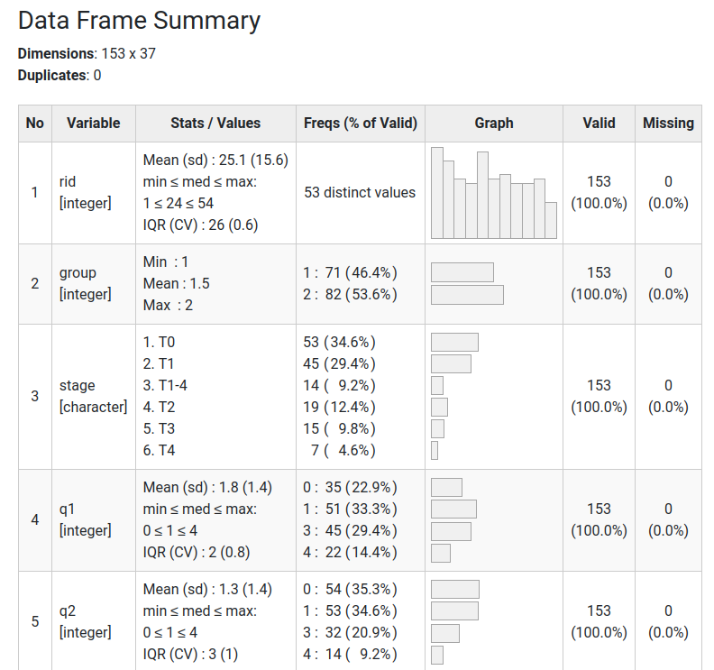

### Data explorer

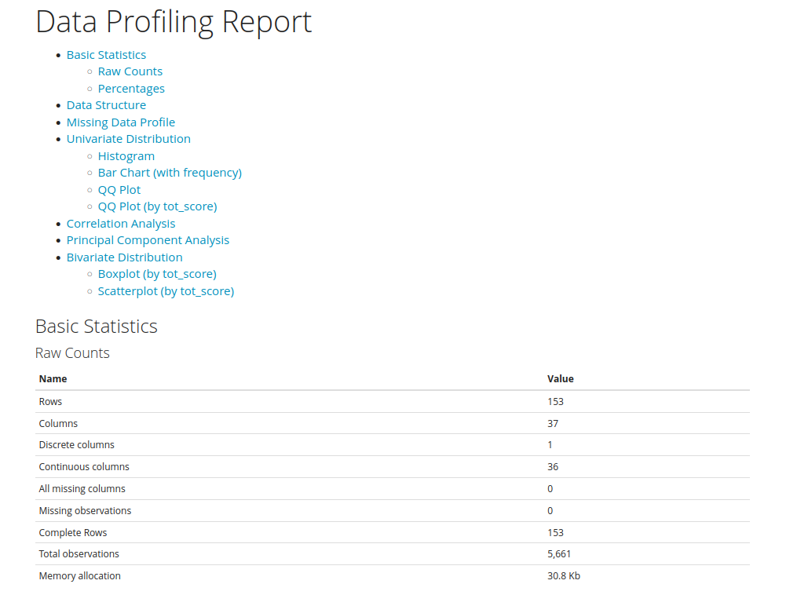

## Demographic Table

Use the `table1` package to create a table with appropriate descriptive information about the data set. Use the examples provided in the [following vignette](https://cran.r-project.org/web/packages/table1/vignettes/table1-examples.html) to help you build a table.

```r
# Load package
library(table1)



Data <- data_demo %>%  select(group,q1_sex,q1_age,q2_edyears, q7_yrstart,q7_tconsume) %>%
   mutate(Group = case_when(group == 1 ~ "Sham",
                           group ==  2 ~ "Treatment"))

str(Data)
```

```
## 'data.frame':    53 obs. of  7 variables:
##  $ group      : int  1 1 2 2 1 1 2 1 1 1 ...
##  $ q1_sex     : int  1 2 1 1 1 1 1 1 2 1 ...
##  $ q1_age     : int  18 44 39 46 37 46 40 33 29 47 ...
##  $ q2_edyears : num  9 12 16 12 16.5 12 18 15 18 13 ...
##  $ q7_yrstart : int  17 41 24 20 24 26 20 20 27 25 ...
##  $ q7_tconsume: num  2 3 12 21 13 20 20 13 3 22 ...
##  $ Group      : chr  "Sham" "Sham" "Treatment" "Treatment" ...
```

```r
Data$group <- as.factor(Data$group)
table1(~ q1_age + q2_edyears+ q7_yrstart+q7_tconsume + q1_sex |  Group , data=Data,   overall = FALSE)
```

|  | Sham (N=23) | Treatment (N=30) |
| --- | --- | --- |
| q1_age |  |  |
| Mean (SD) | 33.3 (8.15) | 36.1 (6.82) |
| Median [Min, Max] | 34.0 [18.0, 47.0] | 36.0 [24.0, 48.0] |
| q2_edyears |  |  |
| Mean (SD) | 13.4 (2.83) | 12.9 (3.06) |
| Median [Min, Max] | 13.0 [8.00, 18.0] | 12.0 [8.00, 19.0] |
| q7_yrstart |  |  |
| Mean (SD) | 22.5 (6.76) | 22.8 (5.81) |
| Median [Min, Max] | 21.0 [14.0, 41.0] | 22.0 [15.0, 35.0] |
| q7_tconsume |  |  |
| Mean (SD) | 9.59 (7.61) | 12.1 (7.68) |
| Median [Min, Max] | 8.00 [1.00, 25.0] | 9.50 [2.00, 30.0] |
| q1_sex |  |  |
| Mean (SD) | 1.13 (0.344) | 1.17 (0.379) |
| Median [Min, Max] | 1.00 [1.00, 2.00] | 1.00 [1.00, 2.00] |

## Data analysis and visualization

```r
data1 <- data_BIS %>%
  filter(stage =="T0"| stage =="T1"| stage =="T2") %>%
  mutate(group = case_when(group == 1 ~ "SHAM",
                           group ==  2 ~ "TMS"))
```

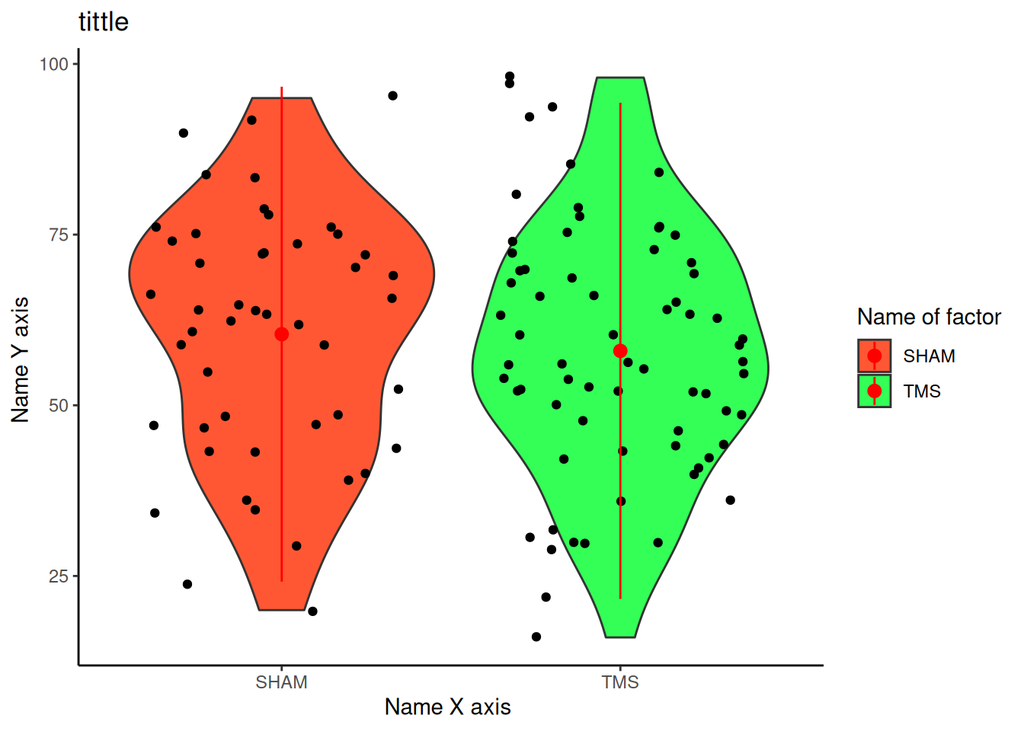

```r
 ggplot(data1, aes(factor(group), tot_score, fill = group))+
  geom_violin() +
  geom_jitter() +
  scale_fill_manual(values = c( "#FF5733","#33FF57"))+

  # Labels
  labs(
    x = "Name X axis ",
    y = "Name Y axis ",
    title = "tittle",
   fill = "Name of factor") +
  # limits
  #ylim(20,40)+
  stat_summary(fun.data=mean_sdl, mult=1,
                 geom="pointrange", color="red")+

  # theme
  theme_classic()
```

Tip: *Use colourpicker::colourPicker() to change the color*

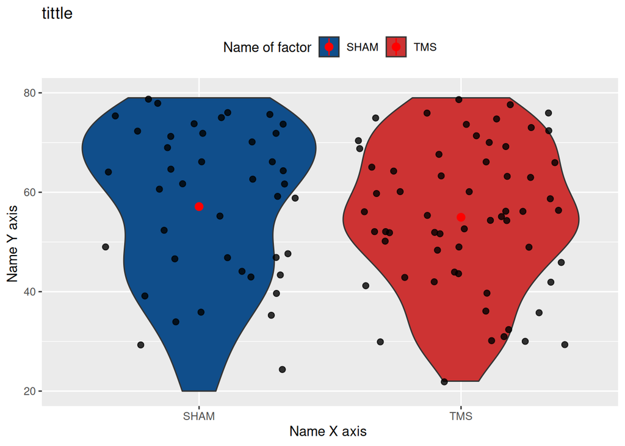

```r
 ggplot(data1, aes(factor(group), tot_score, fill = group))+
  geom_violin() +
  geom_jitter(alpha = 0.8,size = 2) +
  scale_fill_manual(values = c(  "#104E8B", "#CD3333"))+
 # Labels
   labs(
    x = "Name X axis ",
    y = "Name Y axis ",
    title = "tittle",
   fill = "Name of factor") +
# Stats summary
  stat_summary(fun.data=mean_sdl, mult=1,
                 geom="pointrange", color="red")+
# limits
ylim(20,80)+
  # theme
  theme_gray()+
  theme(legend.position = "top")
```

## ggstatsplot

```r
library(ggstatsplot)
```

[ggstatsplot Documentation](https://indrajeetpatil.github.io/ggstatsplot/)

[figure not shown]

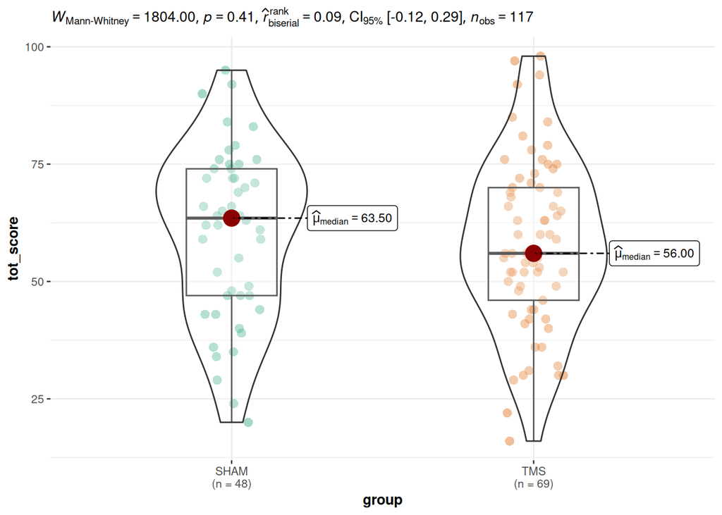

```r
ggstatsplot::ggbetweenstats(data1, x = group, y = tot_score, type = "nonparametric")
```

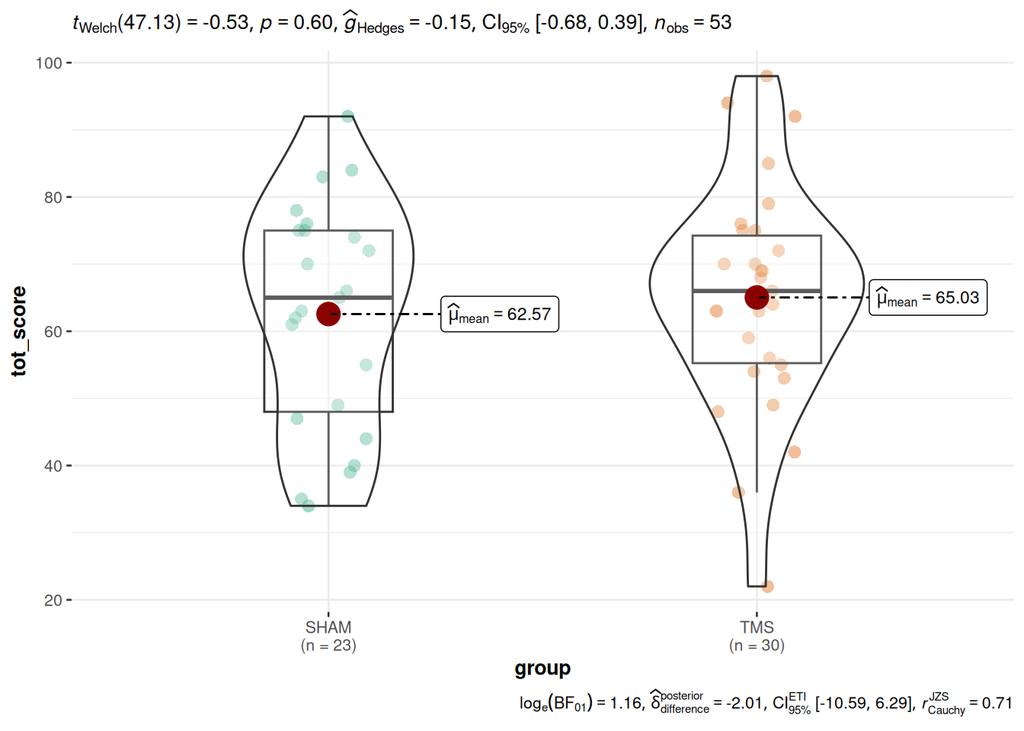

```r
data_t_test <- data_BIS %>%
  filter(stage=="T0")%>%
  mutate(group = case_when(group == 1 ~ "SHAM",
                           group ==  2 ~ "TMS"))

ggstatsplot::ggbetweenstats(data_t_test, x = group, y = tot_score, type = "parametric")
```

## Save the Plots

### Steps:

1- Create your plot . 2- Save the plot to your environment using *<-*.  
3- Use the following commands to save your plot to a file.

```r
plotA <- ggstatsplot::ggbetweenstats(data1, x = group, y = tot_score, type = "parametric")
plotB <- ggstatsplot::ggbetweenstats(data1, x = group, y = cog, type = "parametric")

ggsave("../plots/PlotA.png", plotA, dpi= 300, height = 8, width = 10)
ggsave("../plots/PlotB.tiff", plotB, dpi= 300, height = 8, width = 10)
```

### Combine plot

1- Create your individual plots and assign them to separate variables.  
2- Combine the plots using *ggarrange()*.  
3- Save your plot.

```r
library(ggpubr)
combined_plot <- ggarrange(plotA, plotB, ncol = 2, nrow = 1,
                                     labels = c("A", "B"))

ggsave("../plots/combined_plot.png", combined_plot, dpi= 300, height = 8, width = 10)
```

## What is t-test?

A *t-test* is a statistical method used to compare the means of two groups.

```r
data_t_test <- data_BIS %>%
  filter(stage=="T0")%>%
  mutate(group = case_when(group == 1 ~ "SHAM",
                           group ==  2 ~ "TMS"))

t.test(tot_score~group,
       #alternative = c("two.sided", "less", "greater"),
       conf.level = 0.95,
       #paired = TRUE,
       data = data_t_test)
```

```
##
##  Welch Two Sample t-test
##
## data:  tot_score by group
## t = -0.53238, df = 47.125, p-value = 0.597
## alternative hypothesis: true difference in means between group SHAM and group TMS is not equal to 0
## 95 percent confidence interval:
##  -11.793859   6.857627
## sample estimates:
## mean in group SHAM  mean in group TMS
##           62.56522           65.03333
```

Tip: *Familiarise yourself with the limitations of your data and the limitations of statistical analysis..*

## What is Correlation?

**Correlation Analysis** is statistical method that is used to discover if there is a relationship between two variables/datasets

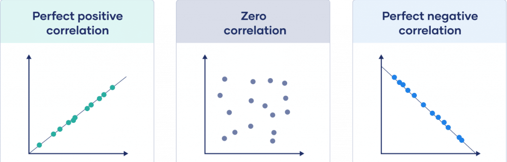

### Load R packages

```r
library(pacman)
pacman::p_load(tidyverse,corrplot)
```

```r
# Data arrangement

data_BIS2 <- data_BIS %>% select(rid,group,stage,cog,mot,nonp,tot_score) %>%
  filter(stage=="T0") %>%
  select(-rid, -group, -stage)
```

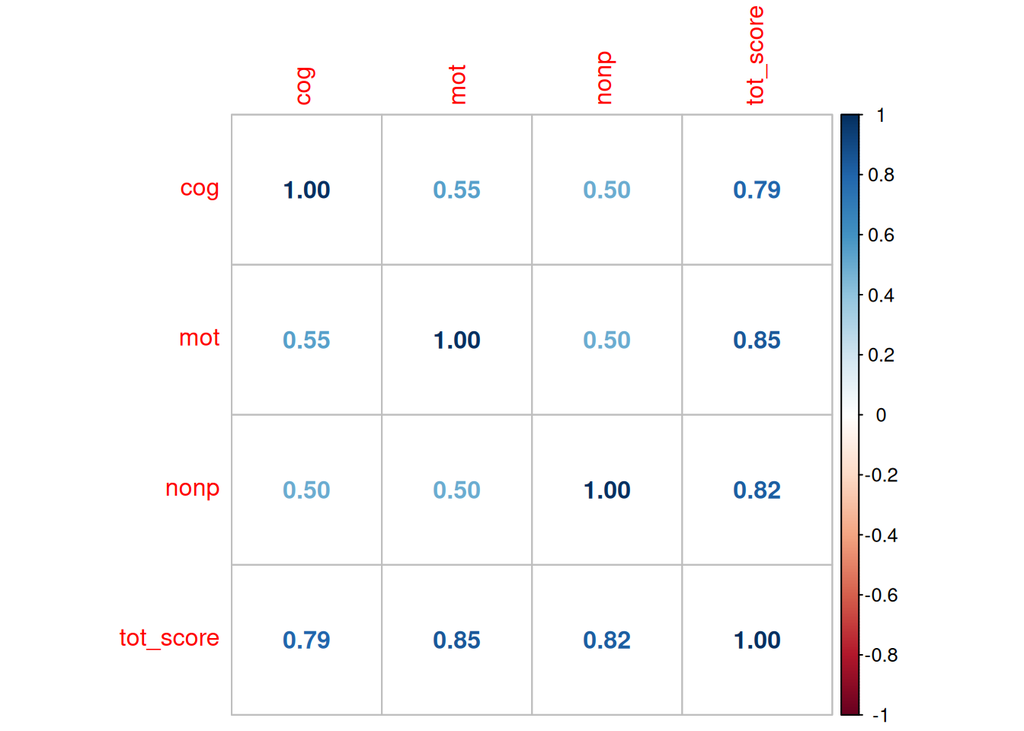

```r
Corr_matrix <-  cor(data_BIS2)

corrplot(Corr_matrix, method = 'number', ) # colorful number
```

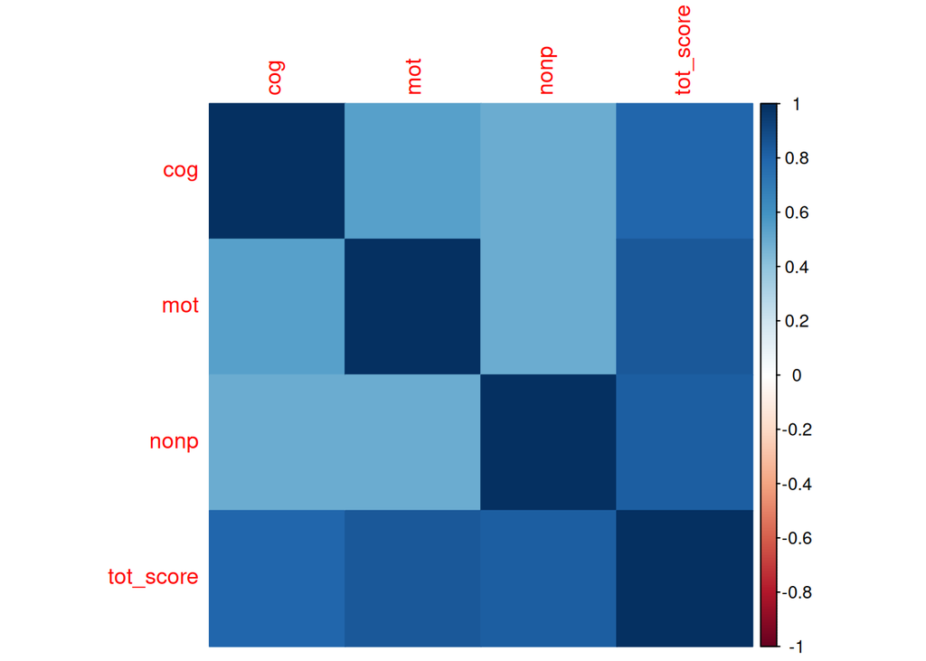

```r
corrplot(Corr_matrix,  method = 'color', order = 'alphabet')
```

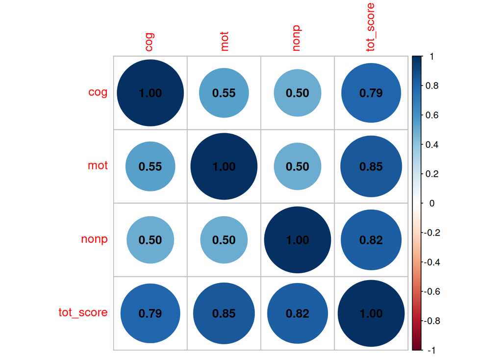

```r
testRes = cor.mtest(data_BIS2, conf.level = 0.95)
corrplot(Corr_matrix, p.mat = testRes$p, method = "circle", sig.level = 0.05,addCoef.col ='black')
```

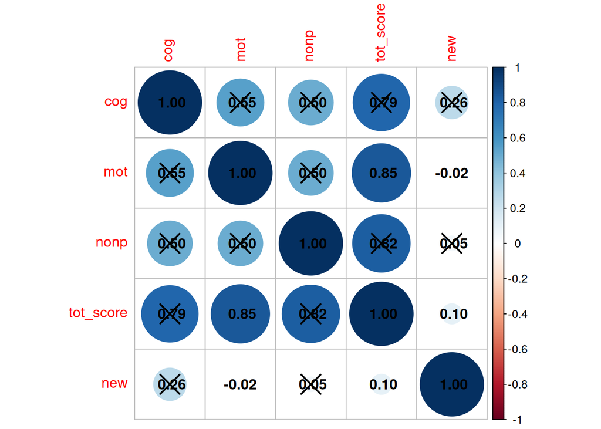

```r
data_BIS3 <- data_BIS2 %>%
  mutate(new = runif(n(), min = 5, max = 50)) %>%
  as.data.frame() %>%
  cor()

testRes = cor.mtest(data_BIS3, conf.level = 0.95)
corrplot(data_BIS3, p.mat = testRes$p, method = "circle", sig.level = 0.05,addCoef.col ='black')
```

### Change the color

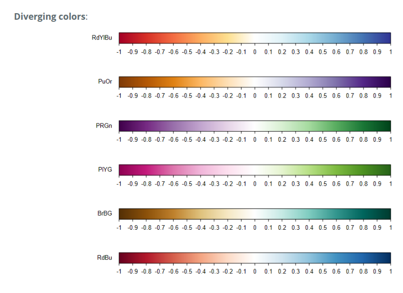

### Example

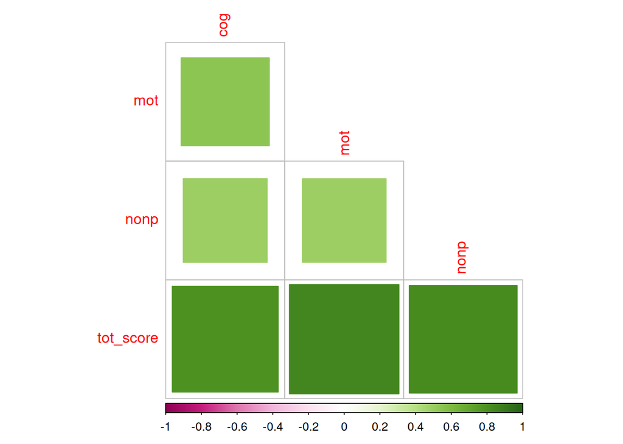

```r
  corrplot(Corr_matrix, method = 'square',  type = 'lower', diag = FALSE,  col = COL2('PiYG'))
```

## What is Regression ?

A linear model specifies a linear relationship between a dependent variable and independent variables, the model takes the form:

$Y ∼ β0 + Xβ1 + ϵ$  
$Y ∼ N ormal(μ, σ)$

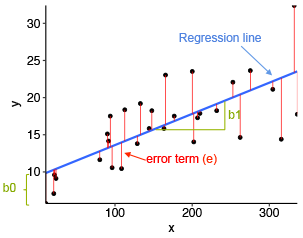

```r
data_B <- data_BIS %>%
  filter(stage=="T0") %>%
  select(rid, BIS_tot=tot_score)

data_H <- data_HDRS %>%
  filter(stage=="T0") %>%
  select(rid, Dep_tot=tot_score)

data_D <- data_demo %>%
  select(rid, sex=q1_sex)



data_full <- full_join(data_B, data_H, by="rid")
data_full <- full_join(data_full, data_D, by="rid")
```

### Before to run the model

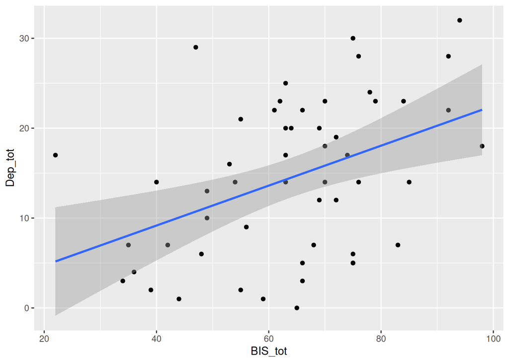

```r
ggplot(data_full,aes(BIS_tot, Dep_tot)) +
  geom_point() + # scatter plot
  geom_smooth(method='lm') # Adjust
```

### Estimate and ruyn the models

```r
model <- lm(BIS_tot~Dep_tot, data=data_full)
summary(model)
```

```
##
## Call:
## lm(formula = BIS_tot ~ Dep_tot, data = data_full)
##
## Residuals:
##     Min      1Q  Median      3Q     Max
## -43.980  -9.413   0.608  10.061  31.216
##
## Coefficients:
##             Estimate Std. Error t value Pr(>|t|)
## (Intercept)  52.3104     4.0729   12.84  < 2e-16 ***
## Dep_tot       0.8041     0.2415    3.33  0.00162 **
## ---
## Signif. codes:  0 '***' 0.001 '**' 0.01 '*' 0.05 '.' 0.1 ' ' 1
##
## Residual standard error: 15.17 on 51 degrees of freedom
## Multiple R-squared:  0.1786, Adjusted R-squared:  0.1625
## F-statistic: 11.09 on 1 and 51 DF,  p-value: 0.001621
```

## Estimate and ruyn the models

```r
model1 <- lm(BIS_tot~Dep_tot, data=data_full)
summary(model1)
```

```
##
## Call:
## lm(formula = BIS_tot ~ Dep_tot, data = data_full)
##
## Residuals:
##     Min      1Q  Median      3Q     Max
## -43.980  -9.413   0.608  10.061  31.216
##
## Coefficients:
##             Estimate Std. Error t value Pr(>|t|)
## (Intercept)  52.3104     4.0729   12.84  < 2e-16 ***
## Dep_tot       0.8041     0.2415    3.33  0.00162 **
## ---
## Signif. codes:  0 '***' 0.001 '**' 0.01 '*' 0.05 '.' 0.1 ' ' 1
##
## Residual standard error: 15.17 on 51 degrees of freedom
## Multiple R-squared:  0.1786, Adjusted R-squared:  0.1625
## F-statistic: 11.09 on 1 and 51 DF,  p-value: 0.001621
```

```r
model2 <- lm(BIS_tot~Dep_tot*sex, data=data_full)
summary(model2)
```

```
##
## Call:
## lm(formula = BIS_tot ~ Dep_tot * sex, data = data_full)
##
## Residuals:
##     Min      1Q  Median      3Q     Max
## -43.631  -9.383   0.608  10.859  29.928
##
## Coefficients:
##              Estimate Std. Error t value Pr(>|t|)
## (Intercept)  65.15279   20.39036   3.195  0.00244 **
## Dep_tot      -0.02575    1.12850  -0.023  0.98188
## sex         -12.25945   19.02407  -0.644  0.52231
## Dep_tot:sex   0.77504    1.03798   0.747  0.45883
## ---
## Signif. codes:  0 '***' 0.001 '**' 0.01 '*' 0.05 '.' 0.1 ' ' 1
##
## Residual standard error: 15.38 on 49 degrees of freedom
## Multiple R-squared:  0.1885, Adjusted R-squared:  0.1388
## F-statistic: 3.794 on 3 and 49 DF,  p-value: 0.01591
```

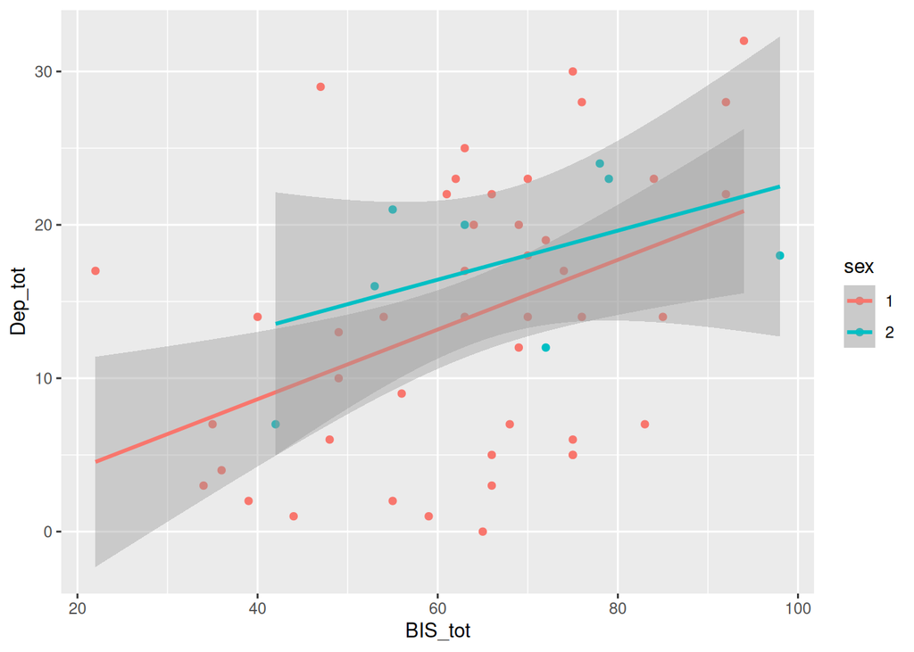

```r
data_full$sex <-as.factor(data_full$sex)
ggplot(data_full, aes(x = BIS_tot, y = Dep_tot, color = sex, group = sex)) +
  geom_point() +
  geom_smooth(method = 'lm', se = T)
```

### Remember !!

A crucial aspect when building regression models is to evaluate the quality of modelfit.

```r
# Load package
library(performance)
```

[figure not shown]

### Check assuptioms

**Linearity:**

Purpose: Checks if the relationship between predictors and the outcome is linear.  
Interpretation: Residuals should be randomly scattered. If most points are around the horizontal line, linearity is likely satisfied.

**Homoscedasticity:**

Purpose: Verifies if residuals have constant variance.  
Interpretation: Residuals should display no clear pattern and be equally spread, indicating constant variance.

**Normality of Residuals:**

Purpose: Examines if residuals are normally distributed.  
Interpretation: Residuals should fall along the reference line in the Q-Q plot. Deviations suggest a departure from normality.

#### Check assuptioms

```r
performance::check_normality(model2)
```

```
## OK: residuals appear as normally distributed (p = 0.861).
```

```r
performance::check_heteroscedasticity(model2)
```

```
## OK: Error variance appears to be homoscedastic (p = 0.942).
```

#### Check for Homogeneity of Variance (Homoscedasticity)

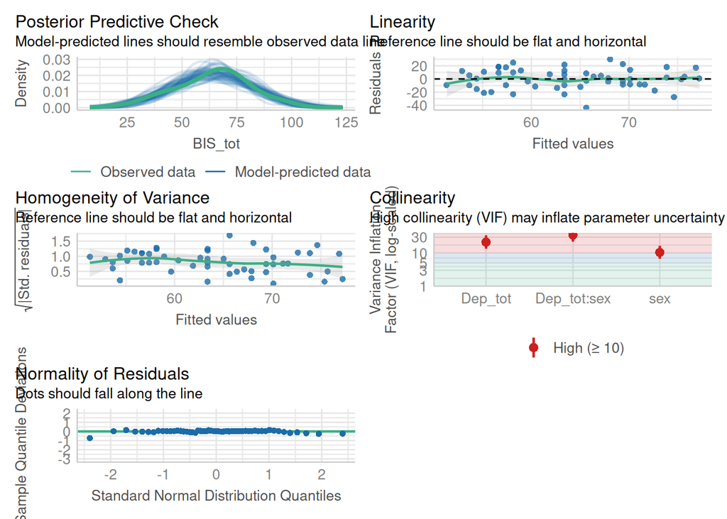

```r
performance::check_model(model2)
```

#### Perfomance of the model

```r
model_performance(model2)
```

```
## # Indices of model performance
##
## AIC     |    AICc |     BIC |    R2 | R2 (adj.) |   RMSE |  Sigma
## -----------------------------------------------------------------
## 445.986 | 447.263 | 455.838 | 0.189 |     0.139 | 14.793 | 15.385
```

#### Model comparison

```r
compare_performance(model, model2 )
```

```
## # Comparison of Model Performance Indices
##
## Name   | Model | AIC (weights) | AICc (weights) | BIC (weights) |    R2 | R2 (adj.) |   RMSE |  Sigma
## -----------------------------------------------------------------------------------------------------
## model  |    lm | 442.6 (0.843) |  443.1 (0.888) | 448.5 (0.975) | 0.179 |     0.162 | 14.883 | 15.172
## model2 |    lm | 446.0 (0.157) |  447.3 (0.112) | 455.8 (0.025) | 0.189 |     0.139 | 14.793 | 15.385
```

#### Check for Homogeneity of Variance (Homoscedasticity)

```r
performance::check_heteroscedasticity(model)
```

```
## OK: Error variance appears to be homoscedastic (p = 0.915).
```

### Model comparison

```r
compare_performance(model, model2 )
```

```
## # Comparison of Model Performance Indices
##
## Name   | Model | AIC (weights) | AICc (weights) | BIC (weights) |    R2 | R2 (adj.) |   RMSE |  Sigma
## -----------------------------------------------------------------------------------------------------
## model  |    lm | 442.6 (0.843) |  443.1 (0.888) | 448.5 (0.975) | 0.179 |     0.162 | 14.883 | 15.172
## model2 |    lm | 446.0 (0.157) |  447.3 (0.112) | 455.8 (0.025) | 0.189 |     0.139 | 14.793 | 15.385
```

### Contact me

**M. Sc. Diego Angeles-Valdez,**  
**PhD Student,**  
University Medical Center Groningen, Cognitive Neuroscience Center,  
Biomedical Sciences of Cells and Systems (BCSS).  
Twitter: [@diegoangls](https://twitter.com/diegoangls)  
Email: d.angeles.valdez@umcg.nl | diego.ang.val@gmail.com  
Work address:P.O. Box 196, 9700 AD GRONINGEN, The Netherlands

[figure not shown]